# Anàlisi Descriptiu: Intervencions del Parlament d’Andalusia

Published

April 24, 2026

## Sobre les dades

Les dades d’aquest informe provenen de la [Videoteca del Parlament d’Andalusia](https://videoteca.parlamentodeandalucia.es) i han estat recollides i processades per una cadena de quatre scripts:

- **`1_scraper_cataleg.R`** — Raspa el catàleg de sessions plenàries de les legislatures X, XI i XII. Per a cada sessió, visita la pàgina `/watch` corresponent i n’extreu l’identificador intern (`id_master`) del bloc JSPLAYLIST, l’única font fiable per a aquest valor.
- **`2_cataleg_diputats.R`** — Construeix el cens de diputats i diputades per a cada legislatura, incloent-hi nom, grup parlamentari i partit.
- **`3_api_sessions.R`** — Descarrega l’esquelet de cada sessió (ordre del dia i oradors) i les transcripcions automàtiques (STT) intervenció per intervenció, a través de l’API interna de la Videoteca.
- **`4_analisi_descriptiu.qmd`** (aquest fitxer) — Fusiona totes les fonts en un CSV unificat (`corpus_intervencions.csv`), una fila per intervenció, amb metadades de sessió, identificació de l’orador i variables derivades per a l’anàlisi de la presència de Catalunya.

## Part 2: Visió general del corpus

### Estadístiques globals

```r
tibble(
  Indicador = c(
    "Legislatures", "Sessions (plens)",
    "Intervencions totals", "Intervencions amb text (≥1 paraula)",
    "Total de paraules", "Mitjana paraules / intervenció",
    "Mediana paraules / intervenció",
    "Oradors únics", "Oradors identificats (diputats + govern)"
  ),
  Valor = c(
    n_distinct(corpus$legislatura),
    n_distinct(corpus$id_master),
    nrow(corpus),
    sum(corpus$n_paraules > 0),
    sum(corpus$n_paraules),
    round(mean(corpus$n_paraules[corpus$n_paraules > 0])),
    median(corpus$n_paraules[corpus$n_paraules > 0]),
    n_distinct(corpus$orador),
    n_distinct(corpus$orador[corpus$orador_identificat])
  )
) |>
  mutate(Valor = formatC(Valor, format = "fg", big.mark = ".")) |>
  kable(align = c("l", "r")) |>
  kable_styling(bootstrap_options = c("striped", "hover"),
                full_width = FALSE, position = "left")
```

Table 1: Estadístiques generals del corpus

| Indicador | Valor |
| --- | --- |
| Legislatures | 1 |
| Sessions (plens) | 100 |
| Intervencions totals | 9.942 |
| Intervencions amb text (≥1 paraula) | 9.940 |
| Total de paraules | 5.316.222 |
| Mitjana paraules / intervenció | 535 |
| Mediana paraules / intervenció | 246 |
| Oradors únics | 129 |
| Oradors identificats (diputats + govern) | 118 |

```r
corpus |>
  group_by(id_master, titol_sessio, fecha) |>
  summarise(n_interv = n(), n_paraules = sum(n_paraules), .groups = "drop") |>
  summarise(
    `Sessions`         = n(),
    `Mínim interv.`    = min(n_interv),
    `Mediana interv.`  = median(n_interv),
    `Màxim interv.`    = max(n_interv),
    `Mínim paraules`   = min(n_paraules),
    `Mediana paraules` = median(n_paraules),
    `Màxim paraules`   = max(n_paraules)
  ) |>
  pivot_longer(everything(), names_to = "Indicador", values_to = "Valor") |>
  mutate(Valor = formatC(Valor, format = "fg", big.mark = ".")) |>
  kable(align = c("l", "r")) |>
  kable_styling(bootstrap_options = c("striped", "hover"),
                full_width = FALSE, position = "left")
```

Table 2: Intervencions per sessió: resum

| Indicador | Valor |
| --- | --- |
| Sessions | 100 |
| Mínim interv. | 1 |
| Mediana interv. | 49.5 |
| Màxim interv. | 229 |
| Mínim paraules | 20 |
| Mediana paraules | 48.997 |
| Màxim paraules | 96.715 |

### Distribució temporal

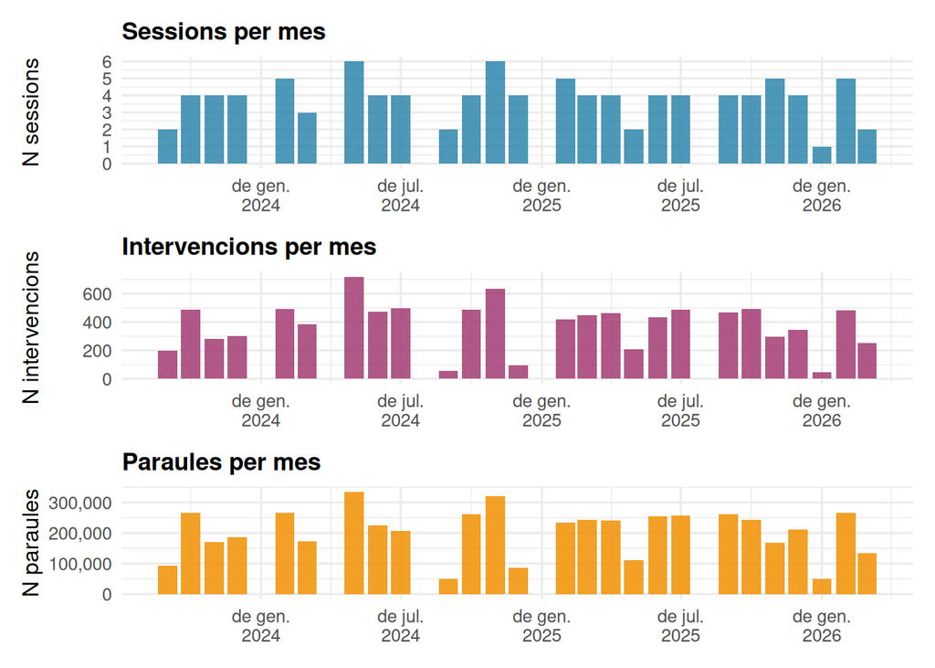

Figure 1: Activitat parlamentària per mes

```r
mensual <- corpus |>
  group_by(data_mes) |>
  summarise(
    n_sessions = n_distinct(id_master),
    n_interv   = n(),
    n_paraules = sum(n_paraules),
    .groups    = "drop"
  )

p_sessions <- ggplot(mensual, aes(x = data_mes, y = n_sessions)) +
  geom_col(fill = "#2E86AB", alpha = 0.85) +
  scale_x_date(date_breaks = "6 months", date_labels = "%b\n%Y") +
  scale_y_continuous(breaks = scales::breaks_pretty()) +
  labs(title = "Sessions per mes", x = NULL, y = "N sessions")

p_interv <- ggplot(mensual, aes(x = data_mes, y = n_interv)) +
  geom_col(fill = "#A23B72", alpha = 0.85) +
  scale_x_date(date_breaks = "6 months", date_labels = "%b\n%Y") +
  scale_y_continuous(labels = label_comma()) +
  labs(title = "Intervencions per mes", x = NULL, y = "N intervencions")

p_paraules <- ggplot(mensual, aes(x = data_mes, y = n_paraules)) +
  geom_col(fill = "#F18F01", alpha = 0.85) +
  scale_x_date(date_breaks = "6 months", date_labels = "%b\n%Y") +
  scale_y_continuous(labels = label_comma()) +
  labs(title = "Paraules per mes", x = NULL, y = "N paraules")

p_sessions / p_interv / p_paraules
```

### Distribució de la longitud de les intervencions

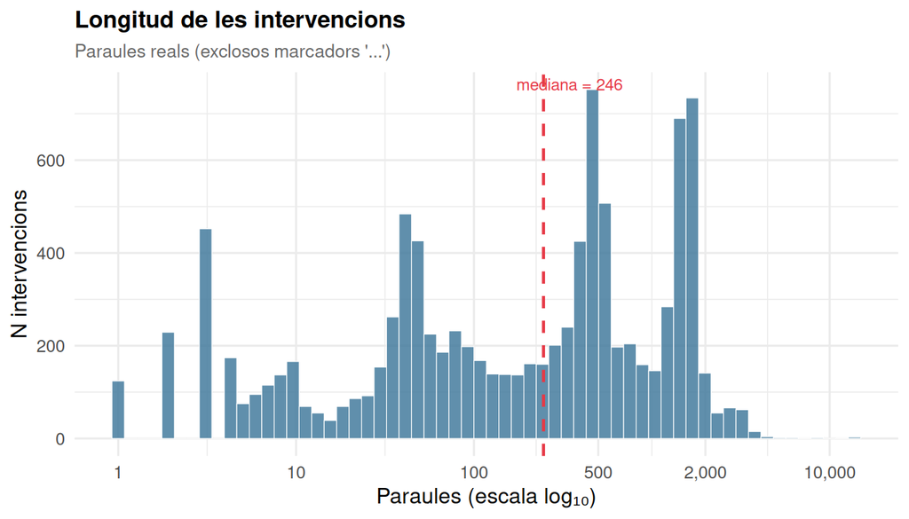

Figure 2: Distribució de la longitud de les intervencions (escala log₁₀)

```r
corpus |>
  filter(n_paraules > 0) |>
  ggplot(aes(x = n_paraules)) +
  geom_histogram(bins = 60, fill = "#457B9D", color = "white", linewidth = 0.2,
                 alpha = 0.85) +
  geom_vline(
    xintercept = median(corpus$n_paraules[corpus$n_paraules > 0]),
    color = "#E63946", linetype = "dashed", linewidth = 0.8
  ) +
  annotate("text",
    x = median(corpus$n_paraules[corpus$n_paraules > 0]) * 1.4,
    y = Inf, vjust = 1.5, size = 3.2, color = "#E63946",
    label = paste0("mediana = ",
                   formatC(median(corpus$n_paraules[corpus$n_paraules > 0]),
                           format = "fg", big.mark = "."))
  ) +
  scale_x_log10(labels = label_comma(), breaks = c(1, 10, 100, 500, 2000, 10000)) +
  scale_y_continuous(labels = label_comma()) +
  labs(title = "Longitud de les intervencions",
       subtitle = "Paraules reals (exclosos marcadors '...')",
       x = "Paraules (escala log₁₀)", y = "N intervencions")
```

### Oradors més actius

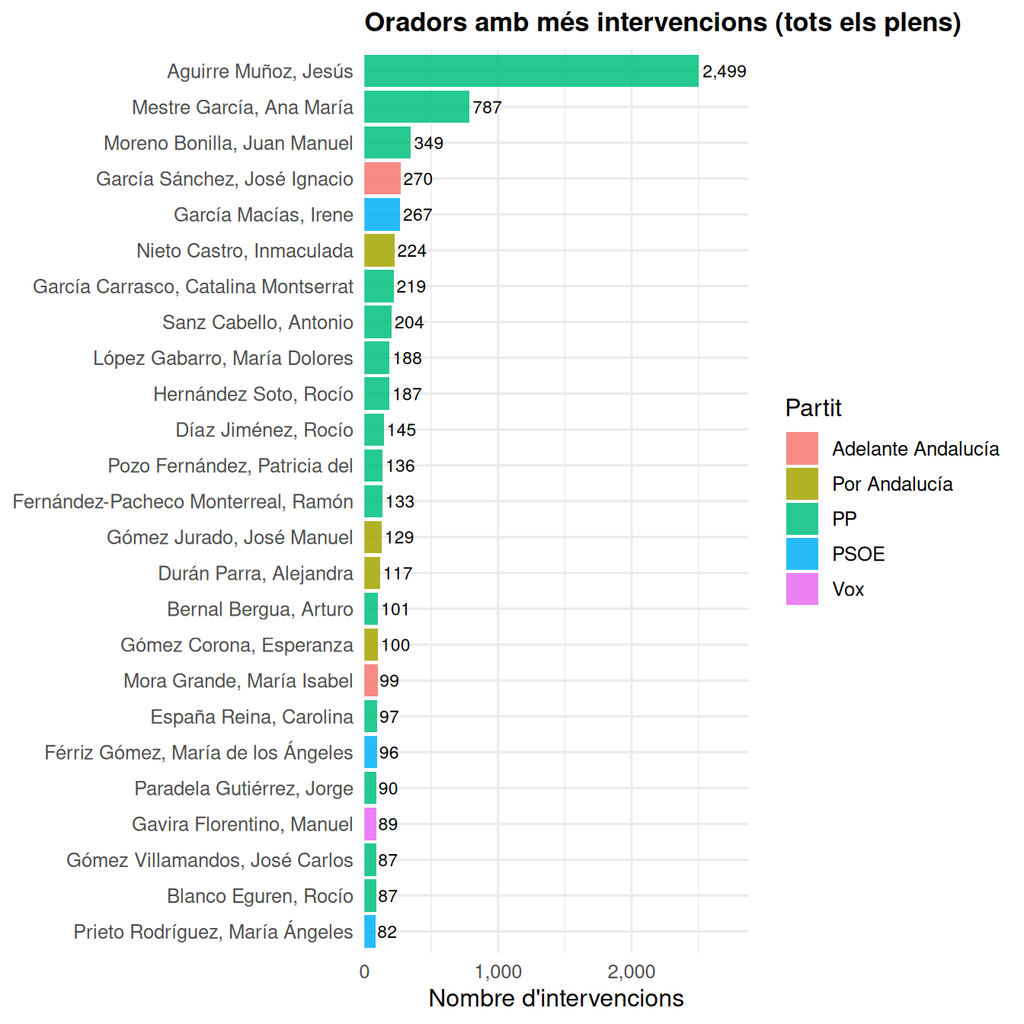

Figure 3: Top 25 oradors per nombre d’intervencions

```r
corpus |>
  filter(orador_identificat) |>
  count(orador, partit, sort = TRUE) |>
  slice_head(n = 25) |>
  mutate(orador = str_trunc(orador, 38) |> fct_reorder(n)) |>
  ggplot(aes(x = n, y = orador, fill = partit)) +
  geom_col(alpha = 0.85) +
  geom_text(aes(label = label_comma()(n)), hjust = -0.1, size = 3) +
  scale_x_continuous(labels = label_comma(),
                     expand = expansion(mult = c(0, 0.15))) +
  labs(title = "Oradors amb més intervencions (tots els plens)",
       x = "Nombre d'intervencions", y = NULL, fill = "Partit") +
  theme(legend.position = "right")
```

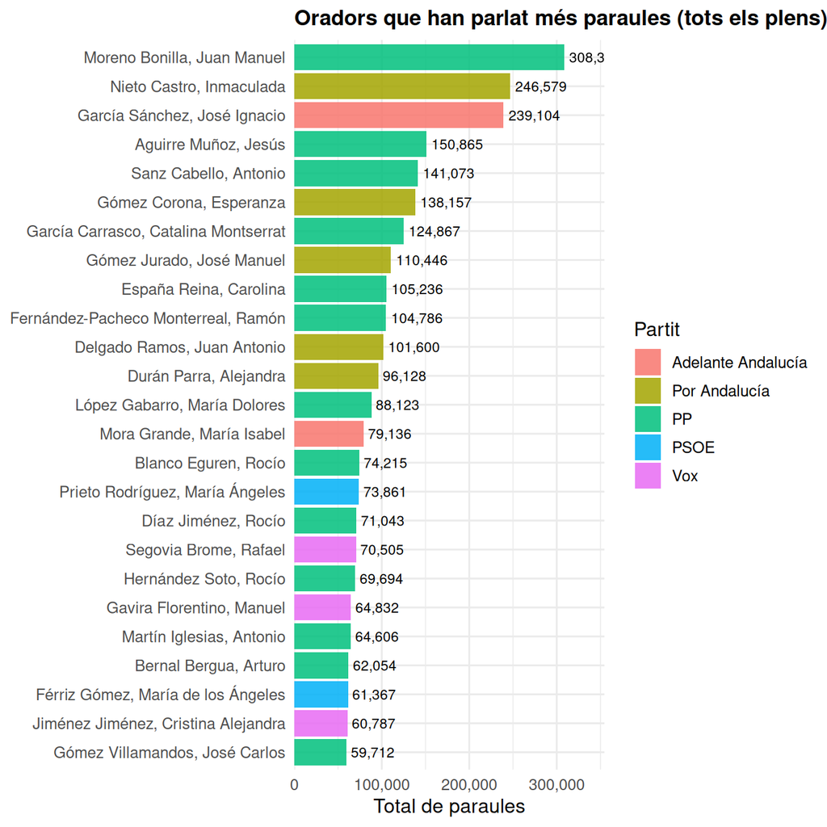

Figure 4: Top 25 oradors per total de paraules

```r
corpus |>
  filter(orador_identificat) |>
  group_by(orador, partit) |>
  summarise(n_paraules = sum(n_paraules), .groups = "drop") |>
  slice_max(n_paraules, n = 25) |>
  mutate(orador = str_trunc(orador, 38) |> fct_reorder(n_paraules)) |>
  ggplot(aes(x = n_paraules, y = orador, fill = partit)) +
  geom_col(alpha = 0.85) +
  geom_text(aes(label = label_comma()(n_paraules)), hjust = -0.1, size = 3) +
  scale_x_continuous(labels = label_comma(),
                     expand = expansion(mult = c(0, 0.15))) +
  labs(title = "Oradors que han parlat més paraules (tots els plens)",
       x = "Total de paraules", y = NULL, fill = "Partit") +
  theme(legend.position = "right")
```

### Repartiment per partit

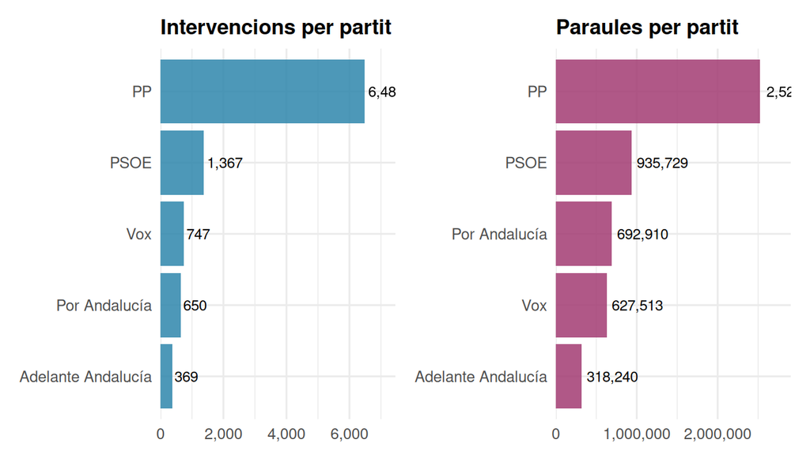

Figure 5: Intervencions i paraules per partit polític

```r
per_partit <- corpus |>
  filter(!is.na(partit)) |>
  group_by(partit) |>
  summarise(n_interv = n(), n_paraules = sum(n_paraules), .groups = "drop")

p_pi <- per_partit |>
  mutate(partit = fct_reorder(partit, n_interv)) |>
  ggplot(aes(x = n_interv, y = partit)) +
  geom_col(fill = "#2E86AB", alpha = 0.85) +
  geom_text(aes(label = label_comma()(n_interv)), hjust = -0.1, size = 3.2) +
  scale_x_continuous(labels = label_comma(),
                     expand = expansion(mult = c(0, 0.15))) +
  labs(title = "Intervencions per partit", x = NULL, y = NULL)

p_pp <- per_partit |>
  mutate(partit = fct_reorder(partit, n_paraules)) |>
  ggplot(aes(x = n_paraules, y = partit)) +
  geom_col(fill = "#A23B72", alpha = 0.85) +
  geom_text(aes(label = label_comma()(n_paraules)), hjust = -0.1, size = 3.2) +
  scale_x_continuous(labels = label_comma(),
                     expand = expansion(mult = c(0, 0.15))) +
  labs(title = "Paraules per partit", x = NULL, y = NULL)

p_pi | p_pp
```

## Part 3: Presència de Catalunya

Definim com a **«menció a Catalunya»** qualsevol intervenció que contingui almenys una ocurrència del patró regex ampliat:

```
(?i)(catalu[ñn]a | catalan(es|as|án)? | independentis(mo|tas?) | separatis(mo|tas?) | golpistas?)
```

Això captura les formes següents:

| Grup | Termes inclosos |
| --- | --- |
| Topònim | *Cataluña*, *Cataluna* |
| Gentilici | *catalán*, *catalana*, *catalanes*, *catalanas*, *catalan* |
| Independentisme | *independentismo*, *independentista*, *independentistas* |
| Separatisme | *separatismo*, *separatista*, *separatistas* |
| Legitimitat | *golpista*, *golpistas* |

El corpus conté a més la columna `mencio_catalunya` basada en el regex restringit (`catalu[ñn]a` únicament), que permet comparar fins a quin punt les mencions directes al topònim i les mencions al debat independentista coincideixen o divergeixen.

```r
corpus_cat <- corpus |> filter(mencio_cat_ext)
```

### Estadístiques generals

```r
tibble(
  Indicador = c(
    "Intervencions amb menció (regex ampliat)",
    "  — d'aquestes, amb topònim Cataluña",
    "% sobre el total d'intervencions",
    "Total de coincidències regex",
    "Oradors únics que mencionen Catalunya",
    "Partits que mencionen Catalunya",
    "Sessions amb almenys una menció"
  ),
  Valor = c(
    formatC(nrow(corpus_cat), format = "fg", big.mark = "."),
    formatC(sum(corpus$mencio_catalunya), format = "fg", big.mark = "."),
    paste0(round(100 * nrow(corpus_cat) / nrow(corpus), 2), "%"),
    formatC(sum(corpus$n_mencions_cat_ext), format = "fg", big.mark = "."),
    as.character(n_distinct(corpus_cat$orador)),
    as.character(n_distinct(corpus_cat$partit[!is.na(corpus_cat$partit)])),
    as.character(n_distinct(corpus_cat$id_master))
  )
) |>
  kable(align = c("l", "r")) |>
  kable_styling(bootstrap_options = c("striped", "hover"),
                full_width = FALSE, position = "left")
```

Table 3: Presència de Catalunya al corpus (regex ampliat)

| Indicador | Valor |
| --- | --- |
| Intervencions amb menció (regex ampliat) | 792 |
| — d'aquestes, amb topònim Cataluña | 544 |
| % sobre el total d'intervencions | 7.97% |
| Total de coincidències regex | 2.079 |
| Oradors únics que mencionen Catalunya | 109 |
| Partits que mencionen Catalunya | 5 |
| Sessions amb almenys una menció | 93 |

### Per partit

```r
corpus |>
  filter(!is.na(partit)) |>
  group_by(Partit = partit) |>
  summarise(
    `Intervencions totals` = n(),
    `Amb Catalunya`        = sum(mencio_cat_ext, na.rm = TRUE),
    `% amb Catalunya`      = round(100 * mean(mencio_cat_ext, na.rm = TRUE), 1),
    `Total mencions`       = sum(n_mencions_cat_ext, na.rm = TRUE),
    `Mencions / interv.`   = round(sum(n_mencions_cat_ext) / n(), 2),
    .groups = "drop"
  ) |>
  arrange(desc(`Amb Catalunya`)) |>
  kable(align = c("l", rep("r", 5))) |>
  kable_styling(bootstrap_options = c("striped", "hover"),
                full_width = FALSE, position = "left")
```

Table 4: Mencions a Catalunya per partit polític (regex ampliat)

| Partit | Intervencions totals | Amb Catalunya | % amb Catalunya | Total mencions | Mencions / interv. |
| --- | --- | --- | --- | --- | --- |
| PP | 6485 | 490 | 7.6 | 1329 | 0.20 |
| Vox | 747 | 112 | 15.0 | 322 | 0.43 |
| PSOE | 1367 | 82 | 6.0 | 200 | 0.15 |
| Por Andalucía | 650 | 64 | 9.8 | 117 | 0.18 |
| Adelante Andalucía | 369 | 30 | 8.1 | 79 | 0.21 |

### Evolució temporal

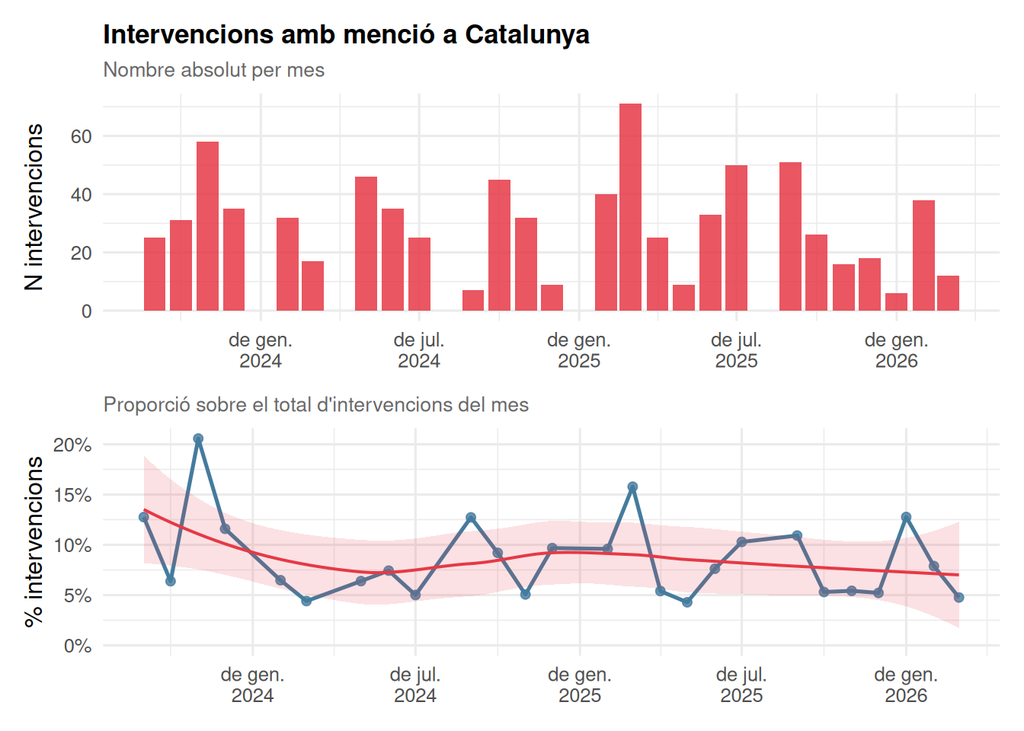

Figure 6: Mencions a Catalunya al llarg del temps

```r
cat_mes <- corpus |>
  filter(!is.na(data_mes)) |>
  group_by(data_mes) |>
  summarise(
    n_total = n(),
    n_cat   = sum(mencio_cat_ext, na.rm = TRUE),
    pct_cat = 100 * n_cat / n_total,
    .groups = "drop"
  )

p_abs <- ggplot(cat_mes, aes(x = data_mes, y = n_cat)) +
  geom_col(fill = "#E63946", alpha = 0.85) +
  scale_x_date(date_breaks = "6 months", date_labels = "%b\n%Y") +
  scale_y_continuous(labels = label_comma()) +
  labs(title = "Intervencions amb menció a Catalunya",
       subtitle = "Nombre absolut per mes",
       x = NULL, y = "N intervencions")

p_pct <- ggplot(cat_mes, aes(x = data_mes, y = pct_cat)) +
  geom_line(color = "#457B9D", linewidth = 0.9) +
  geom_point(color = "#457B9D", size = 1.8, alpha = 0.8) +
  geom_smooth(method = "loess", se = TRUE, color = "#E63946",
              fill = "#E63946", alpha = 0.15, linewidth = 0.7) +
  scale_x_date(date_breaks = "6 months", date_labels = "%b\n%Y") +
  scale_y_continuous(labels = label_percent(scale = 1), limits = c(0, NA)) +
  labs(subtitle = "Proporció sobre el total d'intervencions del mes",
       x = NULL, y = "% intervencions")

p_abs / p_pct
```

### Per partit al llarg del temps

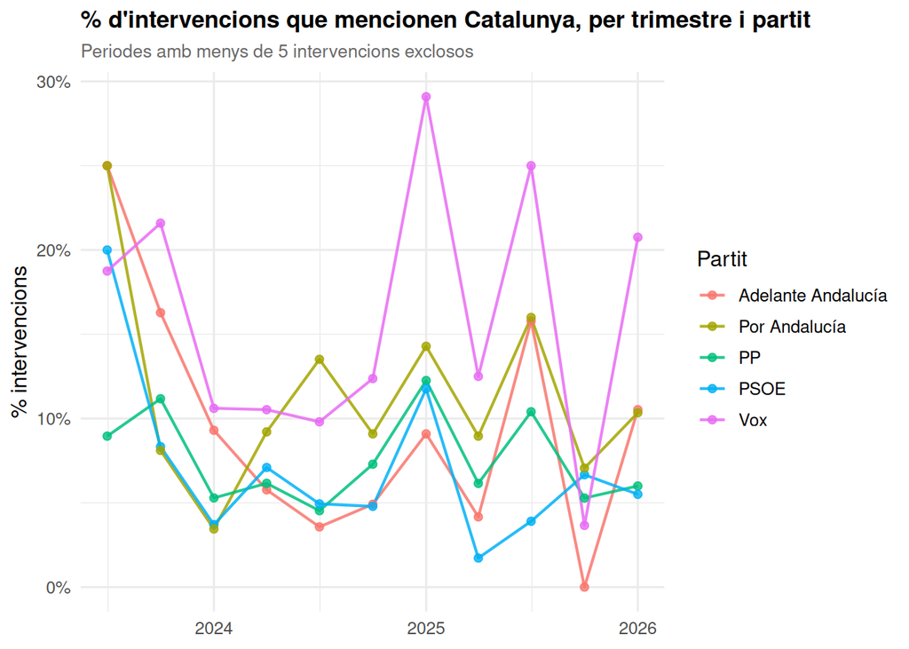

Figure 7: % d’intervencions amb menció a Catalunya per trimestre i partit

```r
corpus |>
  filter(!is.na(partit), !is.na(fecha)) |>
  mutate(data_trim = floor_date(fecha, "quarter")) |>
  group_by(data_trim, partit) |>
  summarise(
    n_total = n(),
    n_cat   = sum(mencio_cat_ext, na.rm = TRUE),
    pct_cat = 100 * n_cat / n_total,
    .groups = "drop"
  ) |>
  filter(n_total >= 5) |>
  ggplot(aes(x = data_trim, y = pct_cat, color = partit)) +
  geom_line(linewidth = 0.75, alpha = 0.85) +
  geom_point(size = 1.8, alpha = 0.8) +
  scale_x_date(date_breaks = "1 year", date_labels = "%Y") +
  scale_y_continuous(labels = label_percent(scale = 1), limits = c(0, NA)) +
  labs(title = "% d'intervencions que mencionen Catalunya, per trimestre i partit",
       subtitle = "Periodes amb menys de 5 intervencions exclosos",
       x = NULL, y = "% intervencions", color = "Partit") +
  theme(legend.position = "right")
```

### Top diputats per mencions a Catalunya

```r
corpus |>
  filter(orador_identificat) |>
  group_by(Orador = orador, Partit = partit) |>
  summarise(
    `Interv. totals`    = n(),
    `Interv. Catalunya` = sum(mencio_cat_ext, na.rm = TRUE),
    `% Catalunya`       = round(100 * mean(mencio_cat_ext, na.rm = TRUE), 1),
    `Total mencions`    = sum(n_mencions_cat_ext, na.rm = TRUE),
    .groups = "drop"
  ) |>
  filter(`Interv. Catalunya` > 0) |>
  slice_max(`Total mencions`, n = 20) |>
  kable(align = c("l", "l", rep("r", 4))) |>
  kable_styling(bootstrap_options = c("striped", "hover"),
                full_width = FALSE, position = "left")
```

Table 5: Top 20 oradors per mencions a Catalunya (regex ampliat)

| Orador | Partit | Interv. totals | Interv. Catalunya | % Catalunya | Total mencions |
| --- | --- | --- | --- | --- | --- |
| Moreno Bonilla, Juan Manuel | PP | 349 | 104 | 29.8 | 288 |
| España Reina, Carolina | PP | 97 | 53 | 54.6 | 272 |
| Jiménez Jiménez, Cristina Alejandra | Vox | 54 | 18 | 33.3 | 112 |
| Martín Iglesias, Antonio | PP | 75 | 25 | 33.3 | 79 |
| García Sánchez, José Ignacio | Adelante Andalucía | 270 | 24 | 8.9 | 70 |
| López Olea, Ricardo | Vox | 64 | 18 | 28.1 | 58 |
| Jiménez Díaz, Mario Jesús | PSOE | 52 | 10 | 19.2 | 56 |
| Nieto Castro, Inmaculada | Por Andalucía | 224 | 18 | 8.0 | 49 |
| Gavira Florentino, Manuel | Vox | 89 | 22 | 24.7 | 44 |
| Repullo Milla, Antonio Jesús | PP | 14 | 8 | 57.1 | 44 |
| Sanz Cabello, Antonio | PP | 204 | 14 | 6.9 | 43 |
| Venzal Contreras, Pablo José | PP | 30 | 14 | 46.7 | 40 |
| López Gabarro, María Dolores | PP | 188 | 18 | 9.6 | 36 |
| Aguilar Román, José Aurelio | PSOE | 58 | 6 | 10.3 | 32 |
| Morillo Alejo, Benito | Vox | 50 | 9 | 18.0 | 32 |
| Mestre García, Ana María | PP | 787 | 8 | 1.0 | 30 |
| Gómez Villamandos, José Carlos | PP | 87 | 18 | 20.7 | 27 |
| Bonilla Hidalgo, Manuel Santiago | PP | 16 | 6 | 37.5 | 25 |
| García Román, José Ricardo | PP | 28 | 10 | 35.7 | 25 |
| Saldaña Moreno, Antonio | PP | 23 | 9 | 39.1 | 25 |

### Proporció per partit

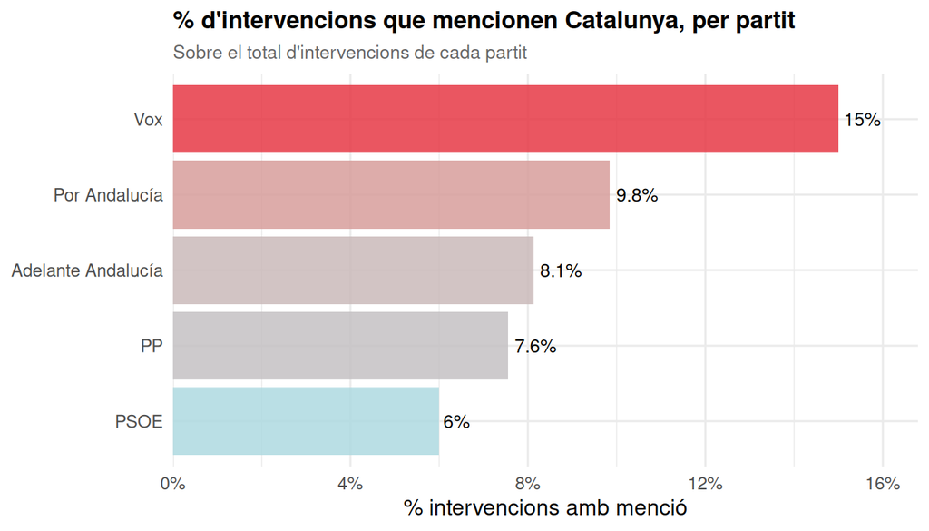

Figure 8: Proporció d’intervencions amb menció a Catalunya per partit

```r
corpus |>
  filter(!is.na(partit)) |>
  group_by(partit) |>
  summarise(
    pct_cat  = 100 * mean(mencio_cat_ext, na.rm = TRUE),
    n_interv = n(),
    .groups  = "drop"
  ) |>
  mutate(
    partit = fct_reorder(partit, pct_cat),
    label  = paste0(round(pct_cat, 1), "%")
  ) |>
  ggplot(aes(x = pct_cat, y = partit)) +
  geom_col(aes(fill = pct_cat), alpha = 0.85, show.legend = FALSE) +
  geom_text(aes(label = label), hjust = -0.15, size = 3.5) +
  scale_fill_gradient(low = "#AED9E0", high = "#E63946") +
  scale_x_continuous(labels = label_percent(scale = 1),
                     expand = expansion(mult = c(0, 0.12))) +
  labs(title = "% d'intervencions que mencionen Catalunya, per partit",
       subtitle = "Sobre el total d'intervencions de cada partit",
       x = "% intervencions amb menció", y = NULL)
```

### Mostra de context: ±200 paraules al voltant de la menció

**Gavira Florentino, Manuel** · 12/06/2025 · 7 menció/ons [▶](https://videoteca.parlamentodeandalucia.es/watch?id=YzViNDY0YzAtZGVmMC00ZmUyLWFjN2MtNDk4ODliYmE0NGU5&start=12988)

*Diario Sesiones Pleno 122 · Leg. 12 · Vox*

gracias, señor presidente. Verdad, señor Moreno, yo después de escucharle esta mañana las primeras palabras que me vienen a la cabeza en relación con su Partido Popular es engaño, fraude y, sobre todo, una gran estafa. Ha hablado usted esta mañana mucho del País Vasco y de Cataluña. Hace una semana el Pleno del Congreso de los Diputados votó con el único voto en contra de Vox –lo voy a repetir– con el único voto en contra de Vox aprobó el Pleno del Congreso de los Diputados la última modificación del concierto económico vasco, con el que el País Vasco aumentará su autogobierno económico financiero con la regulación de hasta 14 impuestos más, entre ellos el IVA. Yo le cuento esto porque en la última sesión de control, señor Moreno, usted me vino a decir, a través del señor Sanz, su Mister Chip particular, que siempre tiene el dato en la tablet, que votamos con los socialistas no sé qué y no sé dónde, con sinceridad. Ustedes votan, señor Moreno, no sólo con los socialistas, con los herederos de los terroristas y con los separatistas golpistas. Y esto, esto lo hacen en contra de los intereses de todos los españoles. En contra de los intereses de todos los españoles. Así que no se preocupen ustedes de lo que vota Vox y que preocúpese mejor de los que votan ustedes y con quién votan ustedes. Porque usted viene aquí, se hace el digno, se pone a hablar del País *[…]*

**Moreno Bonilla, Juan Manuel** · 03/10/2024 · 5 menció/ons [▶](https://videoteca.parlamentodeandalucia.es/watch?id=ODY2MmQ5MzktZDdmMS00NGUzLTk0OTMtZDI5ODlhOGM0MWYy&start=13198)

*Diario Sesiones Pleno 091 · Leg. 12 · PP*

Muchas gracias, señor presidente. Señor Gavira, no sabone usted tampoco a esta alegría de la huerta que tenemos hoy en el Parlamento. Que los datos se pueden ver en todo en la vida. muchas cosas buenas y malas. En la vida todo no es negro ni todo es blanco. Hay datos positivos que dicen que Andalucía ha mejorado notablemente en muchísimos aspectos. Y los conoce, muchos de ellos. Y también hay aspectos en que tenemos que mejorar, evidentemente. Consecuencia también, algo tendrá que ver esos 40 años que hemos tenido de socialismo. Pero mire usted, señor Gavira, es evidente que para mejorar necesitamos más recursos. Y necesitamos más recursos no porque seamos más guapos, más listos o tengamos más necesidades. Simplemente porque somos igual de españoles que el resto de los españoles. Y dentro de ese principio de que somos iguales, nosotros lo que queremos es que un español que vive en Cataluña tenga los mismos derechos, la misma obligación y la misma financiación que un español que vive en Guipúzcoa, que un español que vive en Ferrol o que un español que vive en Ese es el principio que defendemos, que creo que es el principio que usted también defiende. Y por eso nosotros estamos completamente, completamente en contra de las posiciones políticas que se están adoptando por parte del Cuando el señor Sánchez tiene que ganar un mes más en el poder, cuando tiene que ganar una votación en el Congreso o en las Cortes, cada vez que tiene que ganar una noche más en la Moncloa, las estructuras del Estado se resienten, la solidaridad se quiebra, los principios de igualdad tiemblan cada vez que hay una negociación. Y en esas negociaciones, como hemos visto con el cupo independentista, el cupo independentista al final lo que hace es algo tan sencillo que es la vieja reivindicación de aquellos que no quieren compartir con los demás, de aquellos independentistas que son egoístas, que es lo mío primero, lo mío segundo y lo mío también lo tercero, que no quiere compartir con nadie, que no creen en un proyecto común y compartido. Y *[…]*

**García Sánchez, José Ignacio** · 07/02/2024 · 1 menció/ons [▶](https://videoteca.parlamentodeandalucia.es/watch?id=M2EyMDg2YTktZTkwNS00YzQzLWI2MDgtZDY2NWQ0NDQ4YmFi&start=14537)

*Diario Sesiones Pleno 063 · Leg. 12 · Adelante Andalucía*

*[…]* barrio o lo mete en la concertada en la privada concertada señora considera esa es su ideología así de simple es una cuestión organizativa nuna coche ni siquiera económica una cuestión de su ideología porque ocho haciendo una política educativa tremendamente ideológica y otra su derecho porque empezó a decir igual que ideología se haya firmado un convenio con una fundación chiringuito de extrema derecha para que se pasee polo colexio Instituto Andalucía dando charlas con una fundación chiringuito no me creo que en un chiringuito se lo voy a luchar como mucho delito debía leer el nombre del Patronato de la Fundación chiringuito Íñigo Gómez deviene bajo y Zulueta Rocio formal de Mateo Rocío Gómez De Pinedo Fraga el de Íñigo Gómez debido al de María Gómez deviene ráfaga al de Belén Gómez debido formal de esta fundación chiringuito un matrimonio con cuatro y yo y que se va dedica a soltar su adoctrinamiento de extrema derecha polo Concello andaluz diera ese su modelo señora consejera miren esta fundación chiringuito con la cuyo firma un convenio tenía todo volvía a políticos del Partido Popular y de box en su Patronato a fundación chiringuito se dedica a convocar manifestaciones por Cataluña y contra el derecho de la mujer al aborto esta fundación chiringuito su presidente con el puto socia FOTO El otro día tiene frases como le voy a citar exactamente abro comillas ETA no era el problema sino el nacionalismo que atacaba los símbolos nacionales cierro comillas otra perla de este señor con escuchas hace foto hay que quitarle el voto a todo aquello que cobren de lo público supongo se referirá a ello mismo House o lo que estamos aquí por profesionales de la educación o esta es la fundación chiringuito de extrema derecha con lo que usted piensa que hay que educar en los colegios y miré por si acaso sólo ocurre decirlo no me parece perfecto y necesario que se hable del terrorismo de ETA los colegios y que se habla de la víctima está loco yo por supuesto lo que no quiero que lo haga lo grupo ultra excluyente y de extrema derecha que van a soltar su ideología en la que no sabemos la mayoría de los andaluces y andaluzas eso lo que no quieren señora consejera Está usted utilizando a la víctima de ETA en su estrategia partidista del colegio instituto Andalucía y miré *[…]*

**Moreno Bonilla, Juan Manuel** · 15/11/2023 · 1 menció/ons [▶](https://videoteca.parlamentodeandalucia.es/watch?id=YmRhNjAwMDQtY2Q2Yy00YTM3LWEzNDktMjcyNzEwYjlhN2Jk&start=16937)

*Diario Sesiones Pleno 055 · Leg. 12 · PP*

*[…]* hemos entendido de que asumimos el Gobierno haya por por el aire por el mes de enero del año diecinueve tenemos una hoja de ruta definida para continuar mejorando la convergencia nuestra tierra con el resto de España que estabilidad política diálogo seguridad jurídica que lo que busca la mayoría de las empresas inversores y ciudadano estabilidad y seguridad jurídica cosa que se está poniendo evidentemente en solfa en el resto del conjunto del país seguir fortaleciendo nuestra atención sanitaria educativa social y el apoyo familiar sector productivo andaluz se trata de los pilares esenciales que definen el estilo de hacer política ese modelo andaluz que nosotros hemos definido y por poner algunos ejemplo crecemos por encima de España de la Unión Europea comentamos la convergencia la renta por hogar en dos mil diecinueve hecha montón al ochenta y uno coma siete por ciento de la media en dos mil veintidós tan ochenta y cinco coma dos por ciento de la media es reducir la tasa abandono escolar temprano de dos mil dieciocho estamos solo a uno coma cuatro puntos de la media nacional cuando amo casi a siete y por primera vez amo por encima de comunidades como valenciana Cataluña etcétera líderes en autónomo mejorando la competitividad con la media regional de la unió Europea pasando el último año del setenta y uno coma siete al setenta y seis coma seis por tanto es un avance más que importante son datos que reflejan que trabajamos en una en la dirección adecuada pero también deja entrever que queda evidentemente como acabó responder la anterior intervención la sesión de control queda mucho por hacer todavía nos queda mucho por avanzar para conseguir lo objetivo vamos a seguir dotando de todos los instrumentos que posibiliten esa convergencia con el resto de comunidad especialmente la más próspera y para ello es a la ley más importante que presentamos a las de este periodo legislativo que el proyecto de ley dos mil veinticuatro que son las cuenta absolutamente necesaria y por supuesto la marcha reclamando lo que justo en lo que creemos profundamente la igualdad entre todos los ciudadanos y entre todo ciudadano españoles vivamos donde vivamos esa defensa la vamos a hacer la vamos hacer con vehemencia con corrección con determinación pero con educación como siempre solemos hacer las cosas desde luego nos asiste la razón nos asiste la razón sabemos perfectamente que un *[…]*

**Mora Grande, María Isabel** · 28/05/2024 · 1 menció/ons [▶](https://videoteca.parlamentodeandalucia.es/watch?id=ZGQ0ZWFmNTMtYWJkYS00YTI3LWFmMWEtODhmOTE3MDkxOWNk&start=15571)

*Diario Sesiones Pleno 078 · Leg. 12 · Adelante Andalucía*

*[…]* ferrocarril como un medio de comunicación democrático? En vez de pensar tanto en los aves, en la lucha contra el cambio climático, fundamental con el transporte de ferrocarril, que conecte absolutamente todas las comarcas, las medias comarcas, grandes pueblos, donde recibe la mayoría de la población andaluza. Porque me parece que no, con el discurso que nos ha dado. Hace seis meses, desde la Anteandalucía, cuando aquí estuvimos debatiendo en el debate del Estado de la Nación, hicimos una propuesta de resolución que aprobó el Parlamento para que asumieramos las competencias en materia ferroviaria. ¿Sabe usted que esa propuesta de resolución es de obligado cumplimiento? No ha dicho absolutamente nada. Me gustaría saber, después de esos seis meses, qué es lo que ha hecho al respecto, porque eso es su responsabilidad directamente. Después, a los dos meses, se aprobó también una proposición no de ley. Le ha mandado una cartita al ministerio y, como no le han contestado de la manera que usted quería, ya no hecho nada. Porque parece que eso ha sido. No ha dicho absolutamente nada. Esa es su responsabilidad y eso resolvería muchísimos de los problemas que tenemos en Andalucía con el transporte ferroviario. Resulta que Cataluña parece que tiene suficiente poder político como para asumir las competencias en materia ferroviaria. Pero es que ustedes han tenido aquí el respaldo de todo el Parlamento. Y tienen ese poder político. ¿Por qué no lo ejercen? Pues se lo voy a yo decir. Porque en ese momento, cuando lo propusimos, parecía una cuestión andalucista muy interesante. Pero es que ustedes son andalucistas de postureo. Ustedes, mucha soberanía, soberanía sí, pero sobre el papel. Pero cuando la tienen que ejercer, pues ya fallan. Señora consejera, deje de ver lo que no hacen los demás, que muy bien, que ahí podemos estar totalmente de acuerdo. Pero vea también lo que hacen ustedes. Vea lo que no hacen cuando están en Madrid. Dejen de decir que los demás no ven por Andalucía. Porque ustedes tampoco ven por Andalucía. Cuando están en Madrid, estén a la altura. Porque, desde luego, con el debate de hoy no ha estado usted a la altura. Muchas gracias, señora Mora. Pasamos a continuación al Grupo Parlamentario por Andalucía. Y en su nombre la señora Nieto Castro tiene la palabra. SEÑORA Señora Nieto, cuando usted quiera.

**Carmona Sánchez, José Ramón** · 14/12/2023 · 2 menció/ons [▶](https://videoteca.parlamentodeandalucia.es/watch?id=MWY4MjZjNDYtMDJkOC00Y2U4LThlZjctMjhiZjdkZjYxNjFk&start=36915)

*Diario Sesiones Pleno 060 · Leg. 12 · PP*

*[…]* proposición no de ley y la intervención he pronunciado la palabra emitió la primera intervención no en ningún momento pero claro me lo tenían preparado todo lo grupo incluso mi compañera de mesa la señora Gómez por cierto muy constitucionalista son ustedes que son cinco los cinco peleado pero le digo una cosa le digo una cosa le digo una cosa por supuesto pero San Che no preside un gobierno legítimo no presionó vino legítimos hubiera dicho Soy sauce yo no lo he dicho ni lo ha dicho en ningún momento el Partido Popular pero sí le digo que lo que se ha llevado año y año usando el terrorismo no al PP sino Bildu y ahora los otros son ustedes en ciudades como Pamplona y esa misma vergüenza siento decírselo miren que ya que hablamos de nd admitía vamos lo permitía la admitía sí supone negar la existencia del delito y dictar una ley como la Ley de Amnistía tiene lógica quizás en una época pretérito a cómo pasar de un Estado totalitario Estado democrático pero una Amnistía como la que se quiere formular en estos momentos es inconstitucional supone negar la existencia del delito que se cometió en Cataluña supone rechazar una de la garantía de defensa del Estado de derecho pero es que quizás las Lo cierto es que esto no solamente un admitida es la primera auto admitía de lector y a la auto admitía de pero Santi su socio para tapar no para corromper sede del punto de vista de conseguir uno votos solo exclusivamente para mantenerse en el poder a causa de la Amnistía y la nitidez el primer pago ya está moviendo todo lo que hay detrás no hay letra pequeña en letra grande la estamos viendo todo día sí que no podemos asombrar no oímos un poco cosa mañana es todavía más grande la barbaridad que comete el Partido Socialista miren supone la admitía decir que la labor que se ha hecho por los tribunales hasta ahora por la Sala Segunda del Tribunal Supremo se hace de forma arbitraria dice la magistrada maneje su de barco hecha admitía supone negar la existencia del Poder Judicial y negar la función del Poder Judicial es un asalto a la Constitución a la lógica a la defensa de todo derecho un respaldo a los golpistas un respaldo a lo que quieren obligarnos a hacer un referéndum *[…]*

**Bernal Bergua, Arturo** · 11/09/2025 · 2 menció/ons [▶](https://videoteca.parlamentodeandalucia.es/watch?id=Nzc0NjQwNmUtMGI5NC00NWU1LTkzN2EtMGNhMWJhNjA5MGNm&start=8054)

*Diario Sesiones Pleno 130 · Leg. 12 · PP*

Sí, muchísimas gracias, presidente. Buenos días, señorías. Buenos días a todos y bienvenidos nuevamente a este periodo de sesiones. Podemos afirmar que Andalucía sigue consolidándose como un destino internacional, de turismo internacional de primer orden. En los primeros meses estivales los datos nos hablan por sí solos. Solo en el mes de julio hemos recibido a más de un millón y medio de turistas internacionales, que suponen un 5 ,5 % más que en el mismo periodo del año anterior. Este crecimiento es, además, muy superior a la media de España, la media de España que apenas alcanzó el 1 ,6%, Andalucía el 5 ,5%. Andalucía se situó en el mes de julio como el tercer destino preferido para el turismo internacional en España, solamente por detrás de Cataluña y Baleares, con la singularidad de que Cataluña y Baleares incluso decrecieron, como usted muy bien ha indicado, en su número de turistas internacionales, cosa que es muy preocupante porque el turismo internacional es el que, además, tiene el mayor aporte de gasto por persona y día. Andalucía, como digo, si miramos en el acumulado de junio y de julio, hemos recibido un 5 % más de visitantes que el año 2024. Esto se traduce en aproximadamente 140 .000 turistas internacionales que han venido a disfrutar de Andalucía, que han venido a traer empleo y a traer riqueza a Andalucía. Señoría, en la llegada crecemos de manera muy moderada, en el gasto medio crecemos de manera notable. Y esa es la clave. Estamos creciendo moderadamente en el número de turistas y estamos creciendo mucho en materias tan importantes como es el ingreso total y también el empleo que produce el turismo en nuestra tierra. El gasto medio por turista internacional en el mes de julio alcanzó los 191 euros por persona y día. Es un 12 % más que en el año anterior. En conjunto, el gasto de los turistas internacionales en los dos meses de verano supera ya los *[…]*

**Bernal Bergua, Arturo** · 25/10/2023 · 1 menció/ons [▶](https://videoteca.parlamentodeandalucia.es/watch?id=YTVlYjY1ZTItZTllZi00NGEyLTg5YmEtN2Y2MzJiMzk5MWVj&start=12846)

*Diario Sesiones Pleno 053 · Leg. 12 · PP*

gracias Presidenta señor Recio señorías la verdad que lo de la concordia no es una cuestión que me guste ami referir la concordia es una de las expresiones más utilizadas en la exposición de motivos en el preámbulo de la propia ley de los peones cuatro anuales que yo también he referido en la primera parte de mi exposición precisamente la referencia que sobre la concordia y otras materias no eh decía la norma por lo tanto no no considero que la estemos mano sean dos sino que realmente es uno de los objetivos fundamentales creo que uno de los más importantes que tiene la norma cuanto menos y permítame que se lo diga también con todo cariño y con toda empatía igual que usted conmigo cada vez que se refiere a mi cuanto menos un poco forzado utilizar la cuestión de la Amnistía de la de la transición en setenta y ocho para intentar justificar una posición que es injustificable suya y de su Gobierno en relación con la Amnistía a los golpistas del uno de octubre la única justificación señoría para esos ocupar un sillón en la Moncloa Yuste ha comparado a puesto en el mismo nivel la Amnistía del setenta y ocho con la Amnistía para poner en el sillón a al señor Sánchez entonces al gusto explica si quiere o no lo explica todo nosotros me parece que es cuanto menos algo llamativo no miren al Defensor del Pueblo yo tengo aquí las últimas referencias del Defensor del Pueblo precisamente en relación al tema fundamental el tema fundamental que usted parece no darle ninguna importancia y así se la doy me hablaba me hablaba de que el Gobierno de España había invertido cien mil euros les hemos estado persiguiendo durante meses para que la aportación que hacen es así la aportación de cuatrocientos treinta mil euros en los presupuestos del año veintitrés cuatrocientos treinta y seis mil para ser más exactos en total cien mil euros conseguimos que lo dedicarán a identificación de víctimas porque les convence imos de que ya no tenía tanto sentido editar tantísimo aportación a la exhumación porque hay otras vías de financiación que estaban tocando esa rama y sin embargo estamos dejando de tener la *[…]*

**Moreno Bonilla, Juan Manuel** · 14/12/2023 · 4 menció/ons [▶](https://videoteca.parlamentodeandalucia.es/watch?id=MWY4MjZjNDYtMDJkOC00Y2U4LThlZjctMjhiZjdkZjYxNjFk&start=10868)

*Diario Sesiones Pleno 060 · Leg. 12 · PP*

*[…]* son residuales sean limitados solamente reparaciones mejora en accesibilidad y en ningún momento hay ningún proyecto de ampliar la red a pesar de la necesidad que hay en muchas zonas de Andalucía fundamental que el Estado realice un estudio en profundidad en la del estado de la red de cercanías así como la propia gestión que ha hecho el propio operador desde que llegamos al Gobierno diecinueve hemos reclamado de forma reiterada al Gobierno de la Nación la revisión del mapa ferroviario uno más inversión en nuestra red de cercanía pero tambi hemos solicitado algo que no debemos de dejar de pedir que ese fue el tramo litoral corredor Mediterráneo de Almería Granada o la Algeciras Boadilla Antequera la conexión ferroviaria Motril Granada o el tren litoral de la Costa del Sol más inversión en el ámbito ferial Estoy de acuerdo conocen que el ferrocarril de Andalucía está en mal estado lo que perjudica evidentemente la movilidad de una importante número de ciudadanos andaluz le pedí al señor Sancha la gestión de algunos tren Inter Citi no sé si usted se acordará y Media distancia con su financiación y me dijo que no ahora después de lo pactó con los independentista el Gobierno se abre qué curioso cuando Andalucía ante las pasada elecciones legislativas de vía transferencia sea simplemente la gestión o queremos la transferencia no ni siquiera pedimos la transferencia se negaron en rotundo ahora han cambiado opinión Andalucía sufre un doble agrario agravio el déficit de inversión por parte del Estado y la quiebra también de la igualdad por la comunidad autónoma porque qué es esto porque ahora si antes no evidentemente porque han tenido que hacer una cesión que le habían negado la propia ministra de Transporte que había negado la propia autoridad esta propio secretario general de los socialistas catalanes es es la política tenemos detectados en cuanto la pregunta que se me hace Bruce nos otro vamos a ser responsables y vamos a ser siempre leales con el Estado vamos a ser siempre leales con el Estado y por tanto si el Gobierno de España es capaz es capaz de poner no ante ante un documento oficial la misma cantidad la misma cantidad que le ha ofrecido al Gobierno de Cataluña si además con un diagnóstico previo al cómo está el estado de situación de nuestra red de cercanías no sólo estamos dispuestos a asumir y *[…]*

**Nieto Castro, Inmaculada** · 25/07/2024 · 2 menció/ons [▶](https://videoteca.parlamentodeandalucia.es/watch?id=YjRjMGViOGMtMDc4NS00MzE4LThkNGUtYzEwMGM2N2NjZjU4&start=28878)

*Diario Sesiones Pleno 087 · Leg. 12 · Por Andalucía*

*[…]* seguro que ustedes lo conocen. He elegido algunos ejemplos. Mire, esto sobre el Consejo General del Poder Judicial. El 4 de diciembre se cumplieron cinco años del bloqueo del Consejo. Canal Sur Televisión fue el único medio del país que no le dedicó ni un segundo al asunto. Se ocultó incluso las declaraciones del comisario Reinder, pidiendo su renovación inmediata antes de afrontar cualquier reforma legal. Y fíjese lo que dicen los profesionales, señora Lozano. Toda mención a este asunto por los periodistas de Canal Sur, en cola o en cualquier texto sobre la renovación del órgano de gobierno de los jueces, fue borrado por la dirección de informativo. Fíjese usted lo de la independencia y lo de dejar a los periodistas trabajar, que veían ustedes la necesidad de traer aquí a debate, porque…, Mire, le voy a…, fíjese, estos son dos ejemplos, estos son el número 96 y el 97 de las 350. El epígrafe en el que lo engloban es escaletas ideológicas. Se lo digo también por lo de la imparcialidad, que creo que también pone por ahí. El 15 de enero se conoció que el Gobierno de Mariano Rajoy investigó al margen de la ley a partidos independentistas durante cinco años. No existió la información en Canal Sur. Tampoco figuró la noticia en los informativos de Canal Sur sobre la investigación abierta por la Operación Cataluña de espionaje y fabricación de pruebas falsas contra adversarios políticos durante el Gobierno de Mariano Rajoy. El 12 de diciembre…, este es el punto 126. El 12 de diciembre la justicia dio carpetazo al caso Neurona contra mis compañeros y compañeras de Podemos. Y dicen los profesionales de Canal Sur. Canal Sur le dedicó 23 segundos en todo el día. El caso, durante su desarrollo judicial, ocupó minutos y minutos de televisión en los informativos de Canal Sur, con directos y con vídeos explicativos de cada movimiento del juez. Información veraz. Vamos con otra. Sanidad, una de las primeras preocupaciones del pueblo andaluz. El 10 de se celebró un pleno en el Parlamento de Andalucía sobre la situación de la sanidad. No se dio nada en Canal Sur. Solo se emitió un total de la consejera de Salud anunciando el aumento de consultas para salud mental. Nada de la opinión de los portavoces de la oposición sobre cuál es la situación en la que se encuentra la sanidad pública andaluza. Me voy *[…]*

**Jiménez Díaz, Mario Jesús** · 28/09/2023 · 3 menció/ons [▶](https://videoteca.parlamentodeandalucia.es/watch?id=NjBhZTI5MjUtNWU3ZC00N2QwLThiNzEtMGM0YmNkYmIyMDNj&start=26127)

*Diario Sesiones Pleno 050 · Leg. 12 · PSOE*

*[…]* Popular por eso están por eso están enfadados mira cubo frustrada o faltó ne irritable de central y muy muy muy desesperado pero si ustedes no saben ganar señores del Partido Popular como van a saber perder como van a saber perder el alma da la sensación de que piensan que como ha pasado esto si toda la prensa verdadera no decía que por supuesto que ganábamos que ganábamos lo bueno que han pasado que han ganado los comunistas los socialistas los parte Patri revienta España Cómo es posible que les haya pasado ese tiempo yo le digo que llevan dos meses haciendo el ridículo con su estrategia con su un ameno me molestan también era motivo para seguir adelante llevan somete haciendo el ridículo con estrategia y posicionamiento errático y contradictorio alguna pregunta somos ya otra ve un partido de Estado o ya veamos de cero ya son otra vez rompe España digo el Partido Socialista que quieren gobernado cuatro años tres meses y medio un trimestre donde esta noche le eché un un partido con una trayectoria histórica y democrática intachable ou mejor pita dependencias días paro el día impar señores del Partido Popular y el encaje de Cataluña se atrevió a plantear ese término fijo y saben ustedes quién terminó desencantado Feijóo terminó desencantado señores del Partido Popular el PNV dejó el teléfono le lee locuaz al escriben carta simple y llanamente no se entienden con usted y a pesar de su y de su insistencia por cierto la investidura se hacen la calle en el barrio de Salamanca por supuesto señores del Partido Popular gente de bien por supuesto le da mucha pena y alguno de sus dirigente dan un poco de miedo porque sabemos lo que va a empezar ahora a partir de este momento sí sí muy demócratas y todo el mundo sabe lo que va a venir ahora van a reventar la convivencia la instituciones van a soltar los perros de su desvarío como decía Federico contra todos y contra todo lo que no digan lo que ustedes quieren que digan lo que no piensen como ustedes piensan y lo que decidan de manera contraria como Steve decidiría porque parte de España o suya o de nadie o suya o quebrada y no señores del Partido Popular Efe nova hacer camino a partir de mañana a partir de mañana ni Feijóo ni Cuca ni *[…]*

**Herrera Lorente, Trinidad** · 06/11/2024 · 1 menció/ons [▶](https://videoteca.parlamentodeandalucia.es/watch?id=MTc2ZWViNjEtNjEzNS00Y2Q4LWIzNWEtNTc5ZWQ2NzFlYjVm&start=8090)

*Diario Sesiones Pleno 094 · Leg. 12 · PP*

*[…]* las políticas sectarias interesadas e insolidarias del Gobierno de Sánchez para Andalucía. Señorías, cada nuevo empleo creado es un paso hacia adelante, una victoria y un indicador de que, el Gobierno de Sánchez no esté de nuestro lado, nosotros seguimos siempre avanzando. Pero no por ello vamos a dejar de reivindicar lo que nos corresponde. Es evidente que, otras comunidades se benefician de manera significativa a cambio de prevendas políticas, a cambio de mantener a Sánchez en el sillón, Andalucía está infrafinanciada. Señor Bosqué, infrafinanciada. Necesitamos esos 1 .522 millones que injustamente nos quitan y los necesitamos para destinarlos a proyectos que transformen nuestra economía y ofrezcan un futuro digno a los andaluces. No estamos pidiendo limosna, estamos pidiendo lo que en derecho nos corresponde. Y tampoco podemos olvidar que también sufrimos un agravio constante en el reparto de los fondos estatales que financian parte de las políticas activas de empleo, que suponen un 16 ,2 % del total de España frente al 18 % en Andalucía. Pero, si se calcula en función del número de desempleados, todavía los datos son peores. Andalucía recibe 638 euros por cada parado, frente a Baleares, por ejemplo, que recibe 2 .269 euros, o Cataluña 1 .274 euros. La asignación a Andalucía es de 418 euros por debajo de la media nacional. También siguen congelados desde el año 2021 los fondos del plan especial de empleo para Andalucía, además de estar muy bajamente dotados si se compara con otras comunidades autónomas. Un sinfín de agravios y desprecios del Gobierno desancha a los andaluces, y ahí es donde ustedes, los de la izquierda, deberían levantar la voz y defender a los andaluces, que son, en definitiva, los que han permitido que estén ustedes aquí sentados. Pero, señorías, como decía, es importante reconocer y celebrar estos logros y seguir trabajando para que cada andaluz que desee trabajar tenga la oportunidad de hacerlo. Hemos logrado reducir esa tasa de desempleo que no veíamos hace años, un signo claro de que estamos avanzando en la dirección correcta y que refleja la estabilidad y la confianza en nuestro mercado laboral. Hay un aumento en la creación de empresas y cada empresa representa una oportunidad de empleo y un impulso a la innovación y desarrollo económico de nuestra región. Andalucía se está posicionando como un lugar atractivo para invertir y desarrollar ideas, porque es más competitiva fiscalmente, tiene menos trabas burocráticas, *[…]*

## Apèndix A: Membres del Govern de la Junta identificats

```r
gobierno_junta |>
  left_join(
    corpus |>
      filter(orador_identificat) |>
      count(nom_norm = orador_norm, name = "N intervencions"),
    by = "nom_norm"
  ) |>
  mutate(`N intervencions` = replace_na(`N intervencions`, 0L)) |>
  select(Nom = nom, Rol = rol, Partit = partit, `N intervencions`) |>
  arrange(desc(`N intervencions`)) |>
  kable(align = c("l", "l", "l", "r")) |>
  kable_styling(bootstrap_options = c("striped", "hover"),
                full_width = FALSE, position = "left")
```

Table 6: Membres del Govern de la Junta de Andalusia identificats al corpus (llista aproximada)

| Nom | Rol | Partit | N intervencions |
| --- | --- | --- | --- |
| Hernández Soto, Rocío | Consejera de Salud y Familias (XI leg.) | PP | 187 |
| Díaz Jiménez, Rocío | Consejera de Fomento y Articulación Territorial | PP | 145 |
| Fernández-Pacheco Monterreal, Ramón | Consejero de Cultura y Patrimonio Histórico | PP | 133 |
| Bernal Bergua, Arturo | Consejero de Turismo, Cultura y Deporte | PP | 101 |
| España Reina, Carolina | Consejera de Hacienda y Financiación Europea | PP | 97 |
| Paradela Gutiérrez, Jorge | Consejero de Sostenibilidad, Medio Ambiente y Economía Azul | PP | 90 |
| Blanco Eguren, Rocío | Consejera de Empleo, Empresa y Trabajo Autónomo | PP | 87 |
| Gómez Villamandos, José Carlos | Consejero de Universidad, Investigación e Innovación | PP | 87 |
| Nieto Ballesteros, José Antonio | Consejero de Justicia, Administración Local y Función Pública | PP | 78 |
| Crespo Díaz, María Carmen | Consejera de Agricultura, Pesca y Desarrollo Rural (XI leg.) | PP | 49 |

## Apèndix B: Oradors no identificats

```r
corpus |>
  filter(!orador_identificat, n_paraules > 0) |>
  count(orador, sort = TRUE) |>
  slice_head(n = 15) |>
  rename(Orador = orador, `N intervencions` = n) |>
  kable() |>
  kable_styling(bootstrap_options = "striped", full_width = FALSE, position = "left")
```

Table 7: Oradors amb més intervencions sense identificar

| Orador | N intervencions |
| --- | --- |
| Castillo Mena, María del Carmen | 150 |
| Iza de la Torre, Miren Begoñe | 86 |
| Pérez Fernández, Verónica | 30 |
| Cervantes Llort, Montserrat | 23 |
| Morales Sánchez, Mónica | 9 |
| Bautista Lora, Dolores | 8 |
| Egea Fernández-Montesinos, Fernando Arcadio | 7 |
| Lorenzo Cazorla, Juan Antonio | 4 |
| López Gil, Fernando Carlos | 3 |
| Maeztu Gregorio de Tejada, Jesús | 2 |
| Martín Recio, Sebastián | 2 |